# Day 24, Oct 29, 2013

## Topics for the Day

Another **“Day of Theory”**

Review of the factors that shape a confidence interval on a model coefficient.

- Size of residuals
- Amount of data
- Colinearity among explanatory variables

But model coefficients are not the only thing you might want to put a confidence interval on. Other things:

- \( R^2 \) and its friends
- model values and prediction values

## Geometrical Picture of Confidence Intervals

[CI geometry slides](https://dl.dropbox.com/u/5098197/ISM/CI-geometry-slides.pdf)

For coefficients and spread of coefficients as the ball gets bigger, see slides 38 and 39 from [geometry of statistics](https://dl.dropbox.com/u/5098197/ISM/geometry-and-statistics.pdf)

### What's the geometry of the number of data points?

Looking at the distribution of angles between random vectors in 2 and higher dimensions.

#### Ask the class

- if I pick a random vector on the board, what's the distribution of angles to the vector at 12 o'clock? The “spinner problem.”
- What's the distribution of the angle to the vector at 3 o'clock? Should be the same. It doesn't matter where the fixed vector is.
- What's the distribution of the angle between two random vectors? Should be the same.

#### Confirm by simulation

Ask for suggestions for ways to generate a randomly pointing vector in the plane. Perhaps someone will suggest generating a random angle and taking the sine and cosine of that. Good idea, but this assumes that the angles to randomly generated vectors are evenly distributed. And it doesn't generalize to higher dimensions.

Consider two ways to generate random numbers:

- `runif(n, min=-1, max=1)`
- `rnorm(n)`
1. Generate a sample with large n (say n=10000) and report on the distribution.
2. Generate x and y coordinates and plot them:

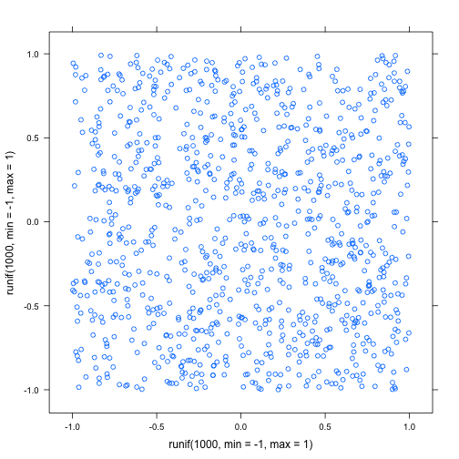

```r
xyplot(runif(1000, min = -1, max = 1) ~ runif(1000, min = -1, max = 1))
```

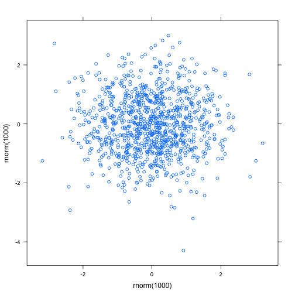

```r
xyplot(rnorm(1000) ~ rnorm(1000))
```

1. Get the distribution of vectors. From trigonometry, remember that the angle will be the arctan of the x and y coordinates. Do `help(atan2)` We'll do a very large simulation (n=100000) so we get a very smooth distribution:

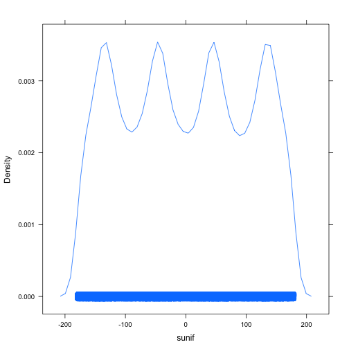

```r
sunif = atan2(runif(1e+05, min = -1, max = 1), runif(1e+05, min = -1, max = 1)) *
    180/pi
densityplot(~sunif)
```

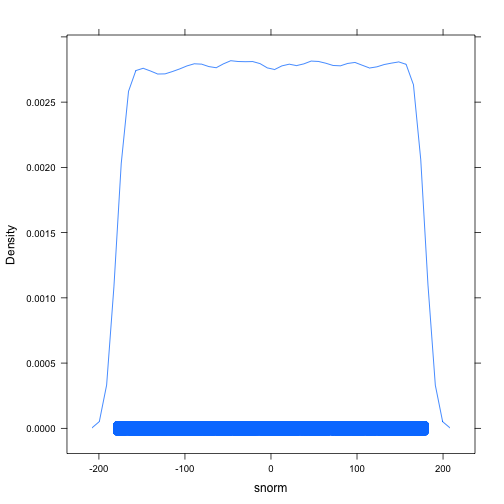

```r
snorm = atan2(rnorm(1e+05), rnorm(1e+05)) * 180/pi
densityplot(~snorm)
```

The uniform distribution doesn't generate uniformly distributed angles, but the normal distribution does.

`atan2()` works in the plane, but we'll want to experiment in higher dimensions as well. So let's calculate the angle based on the dot product.  
Write an angle program. (You'll want to build this up in stages.)

```r
ang = makeFun((180/pi)*acos(sum(u*v)/sqrt(sum(u*u)*sum(v*v)))~
                u&v)
```

Or, if you prefer, use the `angle()` program in `m155development.R`:

```r
fetchData("m155development.R")
```

```
## Retrieving from http://www.mosaic-web.org/go/datasets/m155development.R
```

```
## [1] TRUE
```

Random angles in 2 dimensions:

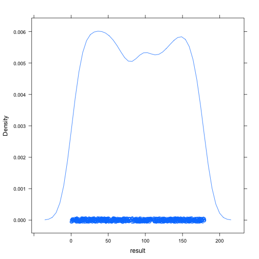

```r
s = do(1000) * angle(rnorm(2), rnorm(2))
densityplot(~result, data = s)
```

The angle is uniform on 0 to 180 degrees. But this intuition is misleading in higher dimensions. Do the same thing in 3 and higher dimensions.

Do the same thing, but replacing one of the vectors with a fixed vector:

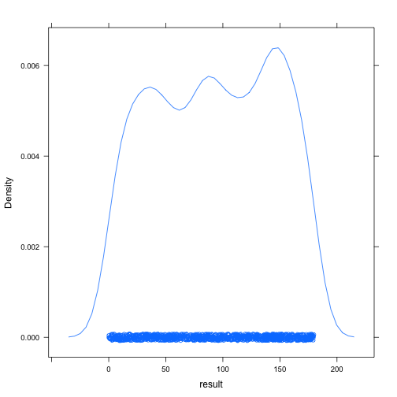

```r
v = rnorm(2)
s = do(1000) * angle(rnorm(2), v)
densityplot(~result, data = s)
```

Now with a 3-dimensional vector:

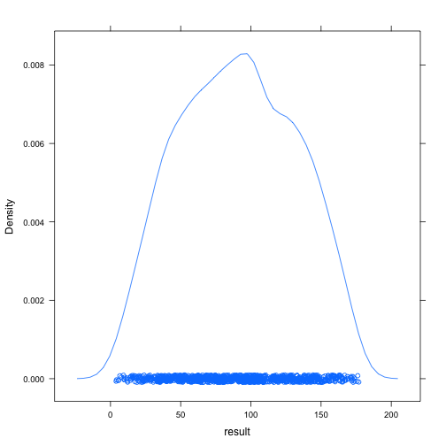

```r
v = rnorm(3)
s = do(1000) * angle(rnorm(3), v)
densityplot(~result, data = s)
```

Why aren't the angles uniformly distributed? Demo: fix one of the vectors at the North Pole. Toss a globe around the room. Report the co-latitude of where your right middle finger lands. (Co-latitude is the angle from the North Pole. So the equator is at 90 deg.) You're much more likely to land near the equator than near the poles.

Now a 30-dimensional vector:

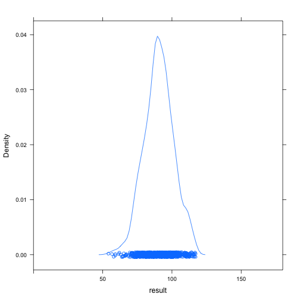

```r
v = rnorm(30)
s = do(1000) * angle(rnorm(30), v)
densityplot(~result, data = s, xlim = c(0, 180))
```

ACTIVITY: Find a simple relationship between the mean angle and n. Find a simple relationship between the variance of the angle and n. Divide people up into 6 groups: 1. use the angle in degrees, study the mean angle 2. use the angle in degrees, study the variance of the angle 3. use the angle in radians, study the mean angle (set `degrees=FALSE` in `angle()`) 4. use the angle in radians, study the variance of the angle. 5. use the cosine of the angle, study the mean cosine of the angle. 6. use the cosine of the angle, study the variance of the angle.

**Suggestions:**

- Use large numbers of simulations, say `do(1000)`
- Construct your theory for fairly large dimension, say 50 to 4000.
- Once you have constructed your theory, see how well it holds for small dimension, say 2 to 5.

**Results** The mean of the random angle is 90deg. The standard deviation of the angle is close to being proportional to \( \sqrt{1}{n} \). Random vectors tend to be orthogonal.

### Back to the Geometry

Since the random vectors will tend to be almost orthogonal to the subspace of the explanatory vectors B and C, the size of the random ball will be reduced. Reduced by how much: a factor of \( \cos(\theta) \).

Overall result: the standard deviation of the cosine of the angle is distributed as \( 1/sqrt(n) \).

# Disastrous Collinearity

Consider a model of wage that incorporates all of these variables: age, educ, exper.

Let's look at them one at a time:

```r
mod0 = lm(wage ~ exper, data = CPS85)
confint(mod0)
```

```
##                 2.5 %  97.5 %
## (Intercept) 7.6159013 9.14403
## exper       0.0009191 0.07136
```

```r
0.07136 - 0.00092
```

```
## [1] 0.07044
```

Putting in covariates can reduce the confidence interval:

```r
mod1 = lm(wage ~ exper + sector * sex, data = CPS85)
head(confint(mod1))
```

```
##                2.5 %  97.5 %
## (Intercept)  5.18536 7.55326
## exper        0.02329 0.08694
## sectorconst -1.24170 4.35135
## sectormanag  1.58599 5.98202
## sectormanuf -3.90760 0.26778
## sectorother -5.32009 2.23733
```

```r
0.08694 - 0.02329
```

```
## [1] 0.06365
```

The interval is reduced because the length of the residual vector has been reduced:

```r
sqrt(sum(resid(mod0)^2))
```

```
## [1] 118.2
```

```r
sqrt(sum(resid(mod1)^2))
```

```
## [1] 103.2
```

What about colinearity with the covariates:

```r
r2 = r.squared(lm(exper ~ sector * sex, data = CPS85))
acos(sqrt(r2)) * 180/pi
```

```
## [1] 78.42
```

```r
1/sin(acos(sqrt(r2)))  # variance inflation: 2%
```

```
## [1] 1.021
```

Now add in another variable, perhaps treated as a covariate or perhaps because we want to untangle the effects of experience and eduction (lower experience is correlated with higher education).

```r
mod3 = lm(wage ~ exper + educ, data = CPS85)
confint(mod3)
```

```
##                2.5 %  97.5 %
## (Intercept) -7.29899 -2.5100
## exper        0.07135  0.1389
## educ         0.76605  1.0859
```

```r
0.1389 - 0.0713
```

```
## [1] 0.0676
```

```r
mod4 = lm(wage ~ exper + educ + sector * sex, data = CPS85)
head(confint(mod4))
```

```
##                2.5 %  97.5 %
## (Intercept) -6.67715 -0.7109
## exper        0.06775  0.1334
## educ         0.52040  0.9139
## sectorconst  0.01977  5.3970
## sectormanag  0.77908  5.0046
## sectormanuf -2.39933  1.6660
```

```r
0.1334 - 0.0677
```

```
## [1] 0.0657
```

Only a small reduction in the width of the confidence interval. Here's the reduction in the length of the residual vector.

```r
sqrt(sum(resid(mod3)^2))
```

```
## [1] 106
```

```r
sqrt(sum(resid(mod4)^2))
```

```
## [1] 98.46
```

Looking at the collinearity introducted by educ

```r
r2 = r.squared(lm(exper ~ educ + sector * sex, data = CPS85))
acos(sqrt(r2)) * 180/pi
```

```
## [1] 64.99
```

```r
1/sin(acos(sqrt(r2)))  # variance inflation: 10%
```

```
## [1] 1.103
```

Now add in age as well

```r
mod5 = lm(wage ~ exper + educ + age + sector * sex, data = CPS85)
head(confint(mod5))
```

```
##                 2.5 % 97.5 %
## (Intercept) -16.89668  9.521
## exper        -2.05383  2.257
## educ         -1.44558  2.882
## age          -2.15431  2.152
## sectorconst   0.01712  5.400
## sectormanag   0.77703  5.007
```

```r
sqrt(sum(resid(mod4)^2))
```

```
## [1] 98.46
```

```r
sqrt(sum(resid(mod5)^2))
```

```
## [1] 98.46
```

but the variance inflation due to collinearity is much larger

```r
r2 = r.squared(lm(exper ~ educ + age + sector * sex, data = CPS85))
acos(sqrt(r2)) * 180/pi  # less than 1 degree!
```

```
## [1] 0.792
```

```r
1/sin(acos(sqrt(r2)))  # variance inflation: 7000% explosion!
```

```
## [1] 72.34
```

As we've seen before, in the CPS85 data, exper was derived from educ and age, but there was a mistake made in one case. Fixing that mistake …

```r
cps = fetchData("CPS85-corrected.csv")
```

```
## Retrieving from http://www.mosaic-web.org/go/datasets/CPS85-corrected.csv
```

```r
mod6 = lm(wage ~ exper + educ + age + sector * sex, data = cps)
head(confint(mod6))
```

```
##                2.5 %  97.5 %
## (Intercept) -6.67715 -0.7109
## exper        0.06775  0.1334
## educ         0.52040  0.9139
## age               NA      NA
## sectorconst  0.01977  5.3970
## sectormanag  0.77908  5.0046
```

When the colinearity is absolute — **redundancy** — the software recognizes the situation and corrects it by deleting a redundant vector from the model.

## Prediction confidence intervals

For prediction or model values, colinearity is not a problem:

```r
mod1 = lm(wage ~ exper + sector * sex, data = CPS85)
r.squared(mod1)
```

```
## [1] 0.243
```

```r
f1 = makeFun(mod1)
f1(exper = 10, sex = "F", sector = "prof", interval = "confidence")
```

```
##     fit   lwr   upr
## 1 10.77 9.518 12.02
```

```r
mod2 = lm(wage ~ exper + educ + sector * sex, data = CPS85)
r.squared(mod2)
```

```
## [1] 0.3113
```

```r
f2 = makeFun(mod2)
f2(exper = 10, educ = 14, sex = "F", sector = "prof", interval = "confidence")
```

```
##     fit   lwr   upr
## 1 9.568 8.329 10.81
```

```r
mod3 = lm(wage ~ exper + educ + age + sector * sex, data = CPS85)
r.squared(mod3)
```

```
## [1] 0.3113
```

```r
f3 = makeFun(mod3)
f3(exper = 10, educ = 14, age = 30, sex = "F", sector = "prof", interval = "confidence")
```

```
##     fit   lwr   upr
## 1 9.568 8.315 10.82
```

## Conclusions

### Effect Size

When you construct a model to estimate an effect size (whether directly from a coefficient or from a partial derivative)

- Use covariates to
  - Adjust for what you want to hold constant in your analysis
  - Reduce the size of the residual and thereby make the confidence interval tight.
  - Watch out for colinearity.

If you absolutely need a colinear covariate for adjustment purposes, and your confidence intervals are too broad, then you'll need to collect more data.

### Prediction/Classification

When you construct a model to make a prediction, you don't need to worry about the colinearity.

The problem with colinearity arises when you want to “share the credit” among 2 or more related (that is, colinear) variables. Since there is an alignment, there is some ambiguity about how to split up credit for the various ways that the residual will point.